# Лабораторная работа №4

Работа с программными пакетами

Юсупова К. Р.

Российский университет дружбы народов, Москва, Россия

# Информация

## Докладчик

- Юсупова Ксения Равилевна
- Российский университет дружбы народов
- Номер студенческого билета- 1132247531
- [1132247531@pfur.ru]

# Вводная часть

## Цель работы

Получить навыки работы с репозиториями и менеджерами пакетов.

## Задание

1. Изучите, как и в каких файлах подключаются репозитории для установки программного обеспечения; изучите основные возможности (поиск, установка, обновление, удаление пакета, работа с историей действий) команды dnf (см. раздел 4.4.1).
2. Изучите и повторите процесс установки/удаления определённого пакета с использованием возможностей dnf (см. раздел 4.4.1).
3. Изучите и повторите процесс установки/удаления определённого пакета с использованием возможностей rpm (см. раздел 4.4.2)

# Выполнение лабораторной работы

В консоли перешли в режим работы суперпользователя и в каталог /etc/yum.repos.d; изучили содержание каталога и файлов репозиториев.

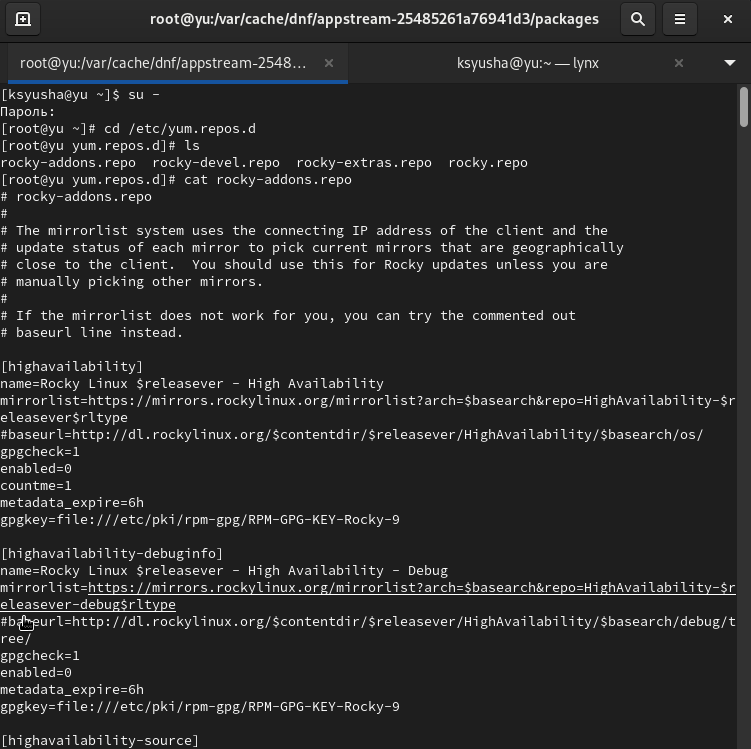

Выполнили пункты 1 и 2 из раздела 4.4.1 (Работа с репозиториями)

## Выполнение лабораторной работы

Вывели на экран список репозиториев и список пакетов, в названии или описании которых есть слово use

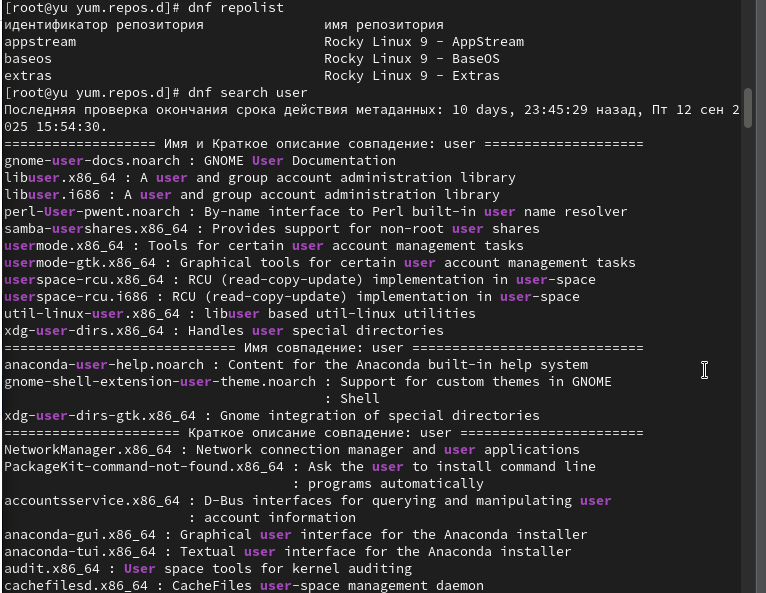

Выполнили пункты 3 и 4 из раздела 4.4.1 (Работа с репозиториями

## Выполнение лабораторной работы

Установили nmap, предварительно изучив информацию по имеющимся пакетам. dnf install nmap — устанавливает только основной пакет nmap, а dnf install nmap* — устанавливает основной пакет nmap и все дополнительные пакеты, имена которых начинаются с “nmap”

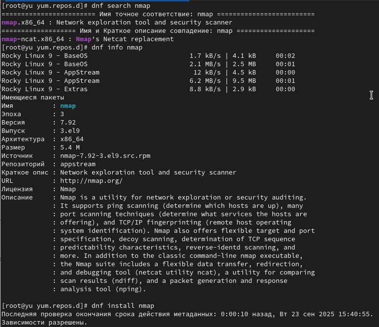

Выполнили пункт 5 из раздела 4.4.1 (Работа с репозиториями

## Выполнение лабораторной работы

Удалили nmap.

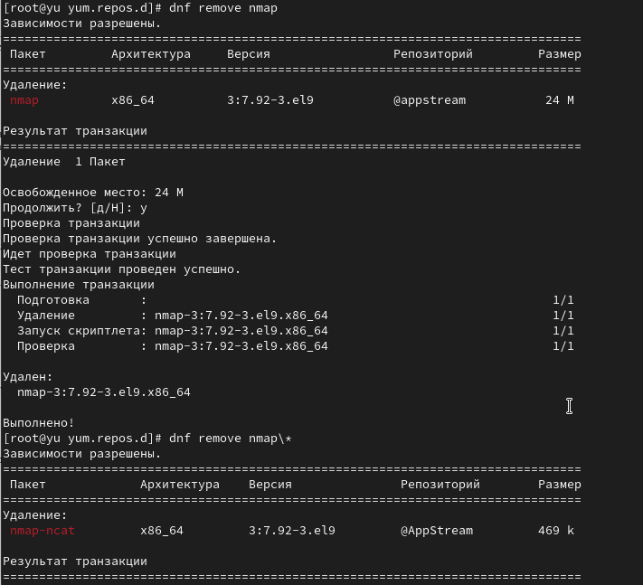

Выполнили пункт 6 из раздела 4.4.1 (Работа с репозиториями

## Выполнение лабораторной работы

Получили список имеющихся групп пакетов, затем установили группу пакетов RPM Development Tools.

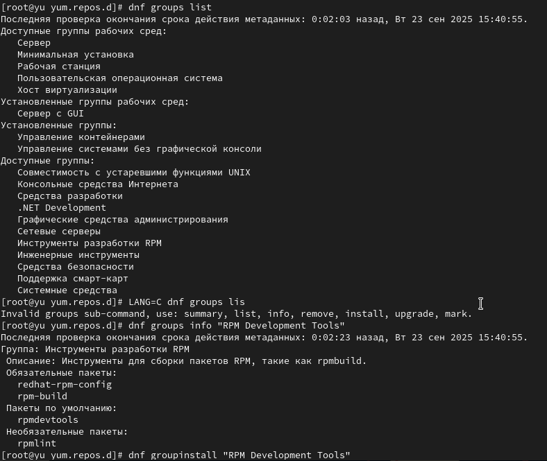

Выполнили пункт 7 из раздела 4.4.1 (Работа с репозиториями)

## Выполнение лабораторной работы

Посмотрели историю использования команды dnf и отменили шестое по счёту, действие.

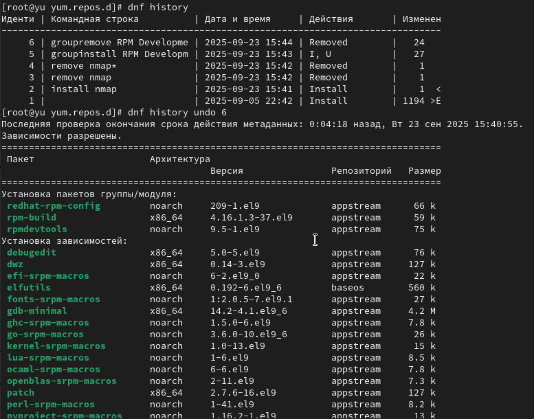

Выполнили пункт 8 из раздела 4.4.1 (Работа с репозиториями)

## Выполнение лабораторной работы

Скачали rpm-пакет lynx и нашли каталог, в который был помещён пакет после загрузки.

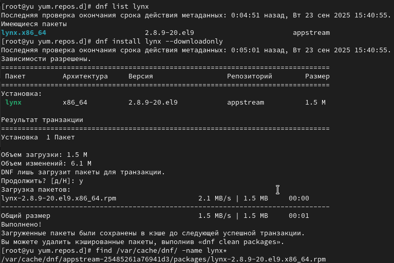

Выполнили пункты 1 и 2 из раздела 4.4.2 (Использование rpm)

## Выполнение лабораторной работы

Перешли в этот каталог и затем установили rpm-пакет; определили расположение исполняемого файла; и используя rpm, определили по имени файла, к какому пакету принадлежит lynx и получили дополнительную информацию о содержимом пакета.

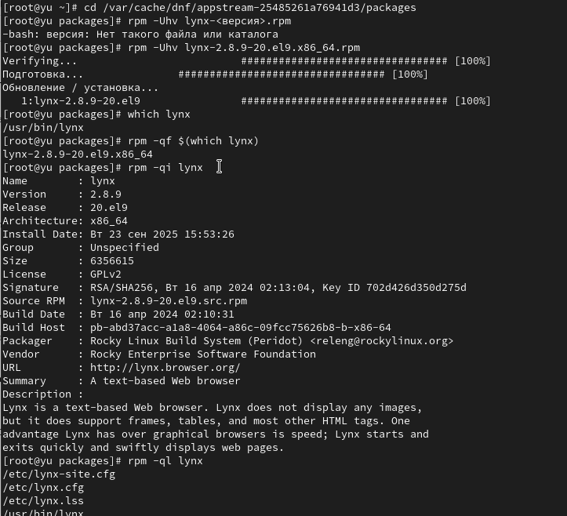

Выполнили пункты 3-5 из раздела 4.4.2 (Использование rpm)

## Выполнение лабораторной работы

Получили список всех файлов в пакете, а также вывели перечень файлов с документацией пакета.

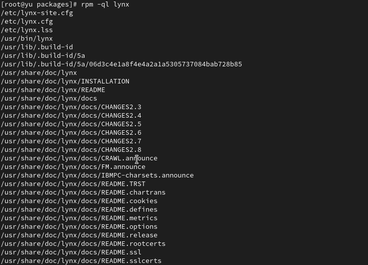

Выполнили пункт 6 из раздела 4.4.2 (Использование rpm)

## Выполнение лабораторной работы

Посмотрели файлы документации, применив команду man lynx; затем вывели на экран перечень и месторасположение конфигурационных файлов пакета и скриптов, выполняемых при установке пакета

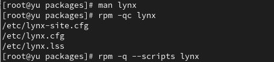

Выполнили пункт 7 и 8 из раздела 4.4.2 (Использование rpm)

## Выполнение лабораторной работы

В отдельном терминале под своей учётной записью запустили текстовый браузер lynx, чтобы проверить корректность установки пакета. Вернулись в терминал с учётной записью root и удалите пакет, потом установили пакет dnsmasq

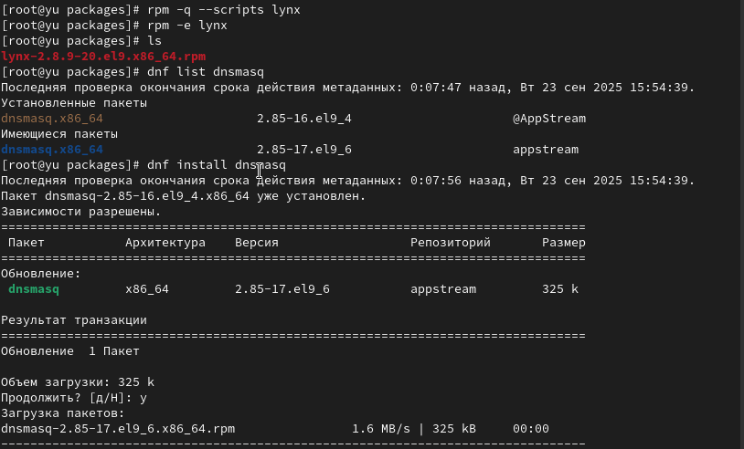

Выполнили пункты 9, 10, 2.1 из раздела 4.4.2 (Использование rpm)

## Выполнение лабораторной работы

Определили расположение исполняемого файла и определили по имени файла, к какому пакету принадлежит dnsmasq;и получили дополнительную информацию о содержимом пакета и список всех файлов в пакете, а также выведили перечень файлов с документацией пакет

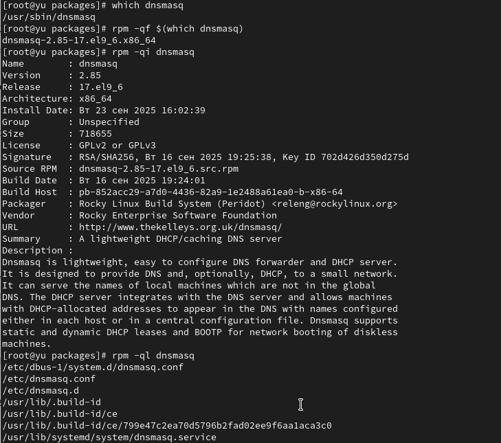

Выполнили пункты 2.2 и 2.3 из раздела 4.4.2 (Использование rpm)

## Выполнение лабораторной работы

Вывели на экран перечень и месторасположение конфигурационных файлов пакета. Затем вывели на экран расположение и содержание скриптов, выполняемых при установке пакета. После вернулись в терминал с учётной записью root и удалили пакет

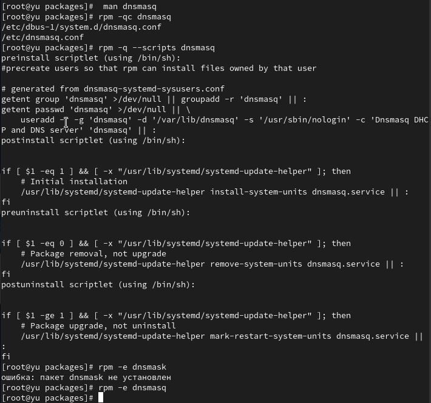

Выполнили пункты 2.4, 2.5 и 2.6 из раздела 4.4.2 (Использование rpm)

# Выводы

В ходе лабораторной работы мы получили навыки работы с репозиториями и менеджерами пакетов.